# Risk Factor Analysis

## Outcome Variable

**Outcome Variable:** pers_wast

## Predictor Variables

**Intervention Variable:** parity

**Adjustment Set:**

- arm
- W_mage
- meducyrs
- feducyrs
- hhwealth_quart
- W_mhtcm
- W_mwtkg
- W_mbmi
- vagbrth
- impsan
- delta_W_mage
- delta_meducyrs
- delta_feducyrs
- delta_hhwealth_quart
- delta_W_mhtcm
- delta_W_mwtkg
- delta_W_mbmi
- delta_vagbrth
- delta_impsan

## Stratifying Variables

The analysis was stratified on these variable(s):

- agecat
- studyid
- country

## Data Summary

| agecat | studyid | country | parity | pers_wast | n_cell | n |
| --- | --- | --- | --- | --- | --- | --- |
| 0-24 months | COHORTS | GUATEMALA | 1 | 0 | 142 | 1053 |
| 0-24 months | COHORTS | GUATEMALA | 1 | 1 | 4 | 1053 |
| 0-24 months | COHORTS | GUATEMALA | 2 | 0 | 144 | 1053 |
| 0-24 months | COHORTS | GUATEMALA | 2 | 1 | 3 | 1053 |
| 0-24 months | COHORTS | GUATEMALA | 3+ | 0 | 731 | 1053 |
| 0-24 months | COHORTS | GUATEMALA | 3+ | 1 | 29 | 1053 |
| 0-24 months | COHORTS | INDIA | 1 | 0 | 550 | 3595 |
| 0-24 months | COHORTS | INDIA | 1 | 1 | 46 | 3595 |
| 0-24 months | COHORTS | INDIA | 2 | 0 | 825 | 3595 |
| 0-24 months | COHORTS | INDIA | 2 | 1 | 73 | 3595 |
| 0-24 months | COHORTS | INDIA | 3+ | 0 | 1853 | 3595 |
| 0-24 months | COHORTS | INDIA | 3+ | 1 | 248 | 3595 |
| 0-24 months | COHORTS | PHILIPPINES | 1 | 0 | 583 | 2811 |
| 0-24 months | COHORTS | PHILIPPINES | 1 | 1 | 24 | 2811 |
| 0-24 months | COHORTS | PHILIPPINES | 2 | 0 | 608 | 2811 |
| 0-24 months | COHORTS | PHILIPPINES | 2 | 1 | 19 | 2811 |
| 0-24 months | COHORTS | PHILIPPINES | 3+ | 0 | 1476 | 2811 |
| 0-24 months | COHORTS | PHILIPPINES | 3+ | 1 | 101 | 2811 |
| 0-24 months | GMS-Nepal | NEPAL | 1 | 0 | 150 | 597 |
| 0-24 months | GMS-Nepal | NEPAL | 1 | 1 | 19 | 597 |
| 0-24 months | GMS-Nepal | NEPAL | 2 | 0 | 130 | 597 |
| 0-24 months | GMS-Nepal | NEPAL | 2 | 1 | 25 | 597 |
| 0-24 months | GMS-Nepal | NEPAL | 3+ | 0 | 237 | 597 |
| 0-24 months | GMS-Nepal | NEPAL | 3+ | 1 | 36 | 597 |
| 0-24 months | JiVitA-3 | BANGLADESH | 1 | 0 | 5444 | 15803 |
| 0-24 months | JiVitA-3 | BANGLADESH | 1 | 1 | 365 | 15803 |
| 0-24 months | JiVitA-3 | BANGLADESH | 2 | 0 | 5185 | 15803 |
| 0-24 months | JiVitA-3 | BANGLADESH | 2 | 1 | 256 | 15803 |
| 0-24 months | JiVitA-3 | BANGLADESH | 3+ | 0 | 4276 | 15803 |
| 0-24 months | JiVitA-3 | BANGLADESH | 3+ | 1 | 277 | 15803 |

[output cut: 144 more lines]

The following strata were considered:

- agecat: 0-24 months, studyid: COHORTS, country: GUATEMALA
- agecat: 0-24 months, studyid: COHORTS, country: INDIA
- agecat: 0-24 months, studyid: COHORTS, country: PHILIPPINES
- agecat: 0-24 months, studyid: GMS-Nepal, country: NEPAL
- agecat: 0-24 months, studyid: JiVitA-3, country: BANGLADESH
- agecat: 0-24 months, studyid: Keneba, country: GAMBIA
- agecat: 0-24 months, studyid: PROVIDE, country: BANGLADESH
- agecat: 0-24 months, studyid: SAS-CompFeed, country: INDIA
- agecat: 0-24 months, studyid: SAS-FoodSuppl, country: INDIA
- agecat: 0-24 months, studyid: TanzaniaChild2, country: TANZANIA, UNITED REPUBLIC OF
- agecat: 0-24 months, studyid: ZVITAMBO, country: ZIMBABWE
- agecat: 0-6 months, studyid: COHORTS, country: PHILIPPINES
- agecat: 0-6 months, studyid: GMS-Nepal, country: NEPAL
- agecat: 0-6 months, studyid: JiVitA-3, country: BANGLADESH
- agecat: 0-6 months, studyid: Keneba, country: GAMBIA
- agecat: 0-6 months, studyid: PROVIDE, country: BANGLADESH
- agecat: 0-6 months, studyid: TanzaniaChild2, country: TANZANIA, UNITED REPUBLIC OF
- agecat: 0-6 months, studyid: ZVITAMBO, country: ZIMBABWE
- agecat: 6-24 months, studyid: COHORTS, country: GUATEMALA
- agecat: 6-24 months, studyid: COHORTS, country: INDIA
- agecat: 6-24 months, studyid: COHORTS, country: PHILIPPINES
- agecat: 6-24 months, studyid: GMS-Nepal, country: NEPAL
- agecat: 6-24 months, studyid: JiVitA-3, country: BANGLADESH
- agecat: 6-24 months, studyid: Keneba, country: GAMBIA
- agecat: 6-24 months, studyid: PROVIDE, country: BANGLADESH
- agecat: 6-24 months, studyid: SAS-CompFeed, country: INDIA
- agecat: 6-24 months, studyid: SAS-FoodSuppl, country: INDIA
- agecat: 6-24 months, studyid: TanzaniaChild2, country: TANZANIA, UNITED REPUBLIC OF
- agecat: 6-24 months, studyid: ZVITAMBO, country: ZIMBABWE

### Dropped Strata

Some strata were dropped due to rare outcomes:

- agecat: 0-24 months, studyid: COHORTS, country: GUATEMALA
- agecat: 0-24 months, studyid: PROVIDE, country: BANGLADESH
- agecat: 0-24 months, studyid: SAS-FoodSuppl, country: INDIA
- agecat: 0-6 months, studyid: JiVitA-3, country: BANGLADESH
- agecat: 0-6 months, studyid: Keneba, country: GAMBIA
- agecat: 0-6 months, studyid: PROVIDE, country: BANGLADESH
- agecat: 0-6 months, studyid: ZVITAMBO, country: ZIMBABWE
- agecat: 6-24 months, studyid: COHORTS, country: GUATEMALA
- agecat: 6-24 months, studyid: PROVIDE, country: BANGLADESH
- agecat: 6-24 months, studyid: SAS-FoodSuppl, country: INDIA

## Methods Detail

We’re interested in the causal parameters $E[Y_a]$ for all values of $a \in \mathcal{A}$. These parameters represent the mean outcome if, possibly contrary to fact, we intervened to set all units to have $A=a$. Under the randomization and positivity assumptions, these are identified by the statistical parameters $\psi_a=E_W[E_{Y|A,W}(Y|A=a,W)]$. In addition, we’re interested in the mean of $Y$, $E[Y]$ under no intervention (the observed mean). We will estimate these parameters by using SuperLearner to fit the relevant likelihood factors – $E_{Y|A,W}(Y|A=a,W)$ and $p(A=a|W)$, and then updating our likelihood fit using a joint TMLE.

For unadjusted analyses ($W=\{\}$), initial likelihoods were estimated using Lrnr_glm to estimate the simple $E(Y|A)$ and Lrnr_mean to estimate $p(A)$. For adjusted analyses, a small library containing Lrnr_glmnet, Lrnr_xgboost, and Lrnr_mean was used.

Having estimated these parameters, we will then use the delta method to estimate relative risks and attributable risks relative to a prespecified baseline level of $A$.

# Results Detail

## Results Plots

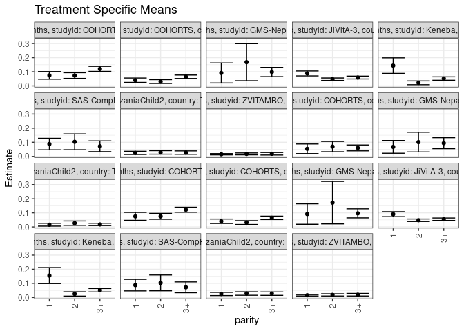

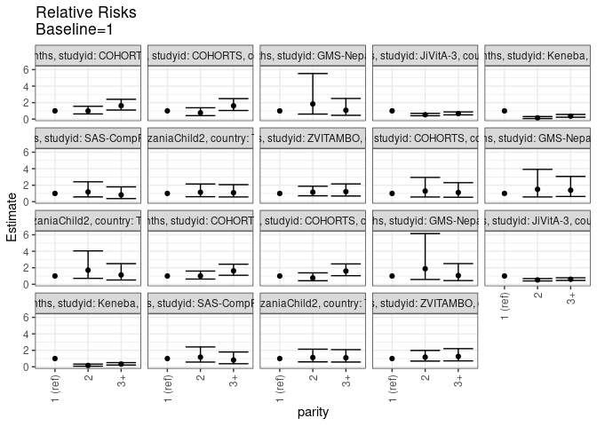

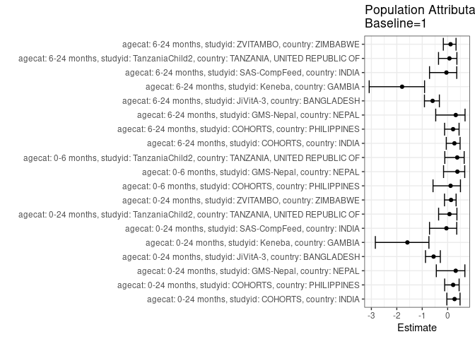

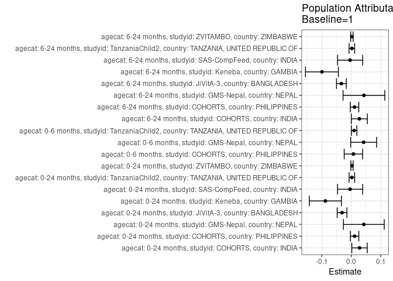

## Results Table

### Parameter: TSM

| agecat | studyid | country | intervention_level | baseline_level | estimate | ci_lower | ci_upper |
| --- | --- | --- | --- | --- | --- | --- | --- |
| 0-24 months | COHORTS | INDIA | 1 | NA | 0.0742809 | 0.0473517 | 0.1012100 |
| 0-24 months | COHORTS | INDIA | 2 | NA | 0.0732867 | 0.0532743 | 0.0932990 |
| 0-24 months | COHORTS | INDIA | 3+ | NA | 0.1206843 | 0.1027803 | 0.1385882 |
| 0-24 months | COHORTS | PHILIPPINES | 1 | NA | 0.0401191 | 0.0244695 | 0.0557688 |
| 0-24 months | COHORTS | PHILIPPINES | 2 | NA | 0.0305286 | 0.0169794 | 0.0440777 |
| 0-24 months | COHORTS | PHILIPPINES | 3+ | NA | 0.0646702 | 0.0525510 | 0.0767894 |
| 0-24 months | GMS-Nepal | NEPAL | 1 | NA | 0.0915147 | 0.0204860 | 0.1625435 |
| 0-24 months | GMS-Nepal | NEPAL | 2 | NA | 0.1679219 | 0.0365209 | 0.2993228 |
| 0-24 months | GMS-Nepal | NEPAL | 3+ | NA | 0.0982511 | 0.0656521 | 0.1308501 |
| 0-24 months | JiVitA-3 | BANGLADESH | 1 | NA | 0.0882298 | 0.0708690 | 0.1055906 |
| 0-24 months | JiVitA-3 | BANGLADESH | 2 | NA | 0.0471861 | 0.0384444 | 0.0559278 |
| 0-24 months | JiVitA-3 | BANGLADESH | 3+ | NA | 0.0589936 | 0.0489465 | 0.0690407 |
| 0-24 months | Keneba | GAMBIA | 1 | NA | 0.1436291 | 0.0883998 | 0.1988584 |
| 0-24 months | Keneba | GAMBIA | 2 | NA | 0.0217091 | 0.0082658 | 0.0351525 |
| 0-24 months | Keneba | GAMBIA | 3+ | NA | 0.0519079 | 0.0396632 | 0.0641526 |
| 0-24 months | SAS-CompFeed | INDIA | 1 | NA | 0.0875464 | 0.0467227 | 0.1283702 |
| 0-24 months | SAS-CompFeed | INDIA | 2 | NA | 0.1034097 | 0.0473879 | 0.1594314 |
| 0-24 months | SAS-CompFeed | INDIA | 3+ | NA | 0.0719805 | 0.0336925 | 0.1102684 |
| 0-24 months | TanzaniaChild2 | TANZANIA, UNITED REPUBLIC OF | 1 | NA | 0.0248090 | 0.0134488 | 0.0361692 |
| 0-24 months | TanzaniaChild2 | TANZANIA, UNITED REPUBLIC OF | 2 | NA | 0.0282113 | 0.0158726 | 0.0405500 |
| 0-24 months | TanzaniaChild2 | TANZANIA, UNITED REPUBLIC OF | 3+ | NA | 0.0269832 | 0.0148932 | 0.0390733 |
| 0-24 months | ZVITAMBO | ZIMBABWE | 1 | NA | 0.0152803 | 0.0107111 | 0.0198495 |
| 0-24 months | ZVITAMBO | ZIMBABWE | 2 | NA | 0.0176949 | 0.0110425 | 0.0243474 |
| 0-24 months | ZVITAMBO | ZIMBABWE | 3+ | NA | 0.0185930 | 0.0095453 | 0.0276406 |
| 0-6 months | COHORTS | PHILIPPINES | 1 | NA | 0.0538922 | 0.0196251 | 0.0881594 |
| 0-6 months | COHORTS | PHILIPPINES | 2 | NA | 0.0695187 | 0.0330444 | 0.1059930 |
| 0-6 months | COHORTS | PHILIPPINES | 3+ | NA | 0.0601202 | 0.0392514 | 0.0809891 |
| 0-6 months | GMS-Nepal | NEPAL | 1 | NA | 0.0674970 | 0.0222534 | 0.1127405 |
| 0-6 months | GMS-Nepal | NEPAL | 2 | NA | 0.1013353 | 0.0318330 | 0.1708375 |
| 0-6 months | GMS-Nepal | NEPAL | 3+ | NA | 0.0938887 | 0.0550429 | 0.1327346 |
| 0-6 months | TanzaniaChild2 | TANZANIA, UNITED REPUBLIC OF | 1 | NA | 0.0156724 | 0.0056803 | 0.0256645 |
| 0-6 months | TanzaniaChild2 | TANZANIA, UNITED REPUBLIC OF | 2 | NA | 0.0266988 | 0.0111403 | 0.0422574 |
| 0-6 months | TanzaniaChild2 | TANZANIA, UNITED REPUBLIC OF | 3+ | NA | 0.0177441 | 0.0094514 | 0.0260368 |
| 6-24 months | COHORTS | INDIA | 1 | NA | 0.0748993 | 0.0468464 | 0.1029522 |
| 6-24 months | COHORTS | INDIA | 2 | NA | 0.0752119 | 0.0544151 | 0.0960087 |
| 6-24 months | COHORTS | INDIA | 3+ | NA | 0.1217665 | 0.1039384 | 0.1395947 |
| 6-24 months | COHORTS | PHILIPPINES | 1 | NA | 0.0402514 | 0.0245822 | 0.0559206 |
| 6-24 months | COHORTS | PHILIPPINES | 2 | NA | 0.0308574 | 0.0172072 | 0.0445075 |
| 6-24 months | COHORTS | PHILIPPINES | 3+ | NA | 0.0645049 | 0.0523886 | 0.0766212 |
| 6-24 months | GMS-Nepal | NEPAL | 1 | NA | 0.0912874 | 0.0187174 | 0.1638573 |
| 6-24 months | GMS-Nepal | NEPAL | 2 | NA | 0.1719640 | 0.0215729 | 0.3223550 |
| 6-24 months | GMS-Nepal | NEPAL | 3+ | NA | 0.0963412 | 0.0643630 | 0.1283195 |
| 6-24 months | JiVitA-3 | BANGLADESH | 1 | NA | 0.0904593 | 0.0729133 | 0.1080052 |
| 6-24 months | JiVitA-3 | BANGLADESH | 2 | NA | 0.0474382 | 0.0385494 | 0.0563271 |
| 6-24 months | JiVitA-3 | BANGLADESH | 3+ | NA | 0.0547195 | 0.0459399 | 0.0634991 |
| 6-24 months | Keneba | GAMBIA | 1 | NA | 0.1552157 | 0.0984909 | 0.2119405 |
| 6-24 months | Keneba | GAMBIA | 2 | NA | 0.0251825 | 0.0098985 | 0.0404665 |
| 6-24 months | Keneba | GAMBIA | 3+ | NA | 0.0515680 | 0.0395898 | 0.0635462 |
| 6-24 months | SAS-CompFeed | INDIA | 1 | NA | 0.0875464 | 0.0467227 | 0.1283702 |
| 6-24 months | SAS-CompFeed | INDIA | 2 | NA | 0.1034097 | 0.0473879 | 0.1594314 |
| 6-24 months | SAS-CompFeed | INDIA | 3+ | NA | 0.0719805 | 0.0336925 | 0.1102684 |
| 6-24 months | TanzaniaChild2 | TANZANIA, UNITED REPUBLIC OF | 1 | NA | 0.0248561 | 0.0134631 | 0.0362492 |
| 6-24 months | TanzaniaChild2 | TANZANIA, UNITED REPUBLIC OF | 2 | NA | 0.0281698 | 0.0158082 | 0.0405313 |
| 6-24 months | TanzaniaChild2 | TANZANIA, UNITED REPUBLIC OF | 3+ | NA | 0.0273027 | 0.0151578 | 0.0394476 |
| 6-24 months | ZVITAMBO | ZIMBABWE | 1 | NA | 0.0156171 | 0.0106937 | 0.0205405 |
| 6-24 months | ZVITAMBO | ZIMBABWE | 2 | NA | 0.0183429 | 0.0106307 | 0.0260551 |
| 6-24 months | ZVITAMBO | ZIMBABWE | 3+ | NA | 0.0196363 | 0.0105339 | 0.0287386 |

### Parameter: E(Y)

| agecat | studyid | country | intervention_level | baseline_level | estimate | ci_lower | ci_upper |
| --- | --- | --- | --- | --- | --- | --- | --- |
| 0-24 months | COHORTS | INDIA | NA | NA | 0.1020862 | 0.0921879 | 0.1119845 |
| 0-24 months | COHORTS | PHILIPPINES | NA | NA | 0.0512273 | 0.0430760 | 0.0593786 |
| 0-24 months | GMS-Nepal | NEPAL | NA | NA | 0.1340034 | 0.1066544 | 0.1613523 |
| 0-24 months | JiVitA-3 | BANGLADESH | NA | NA | 0.0568247 | 0.0527145 | 0.0609348 |
| 0-24 months | Keneba | GAMBIA | NA | NA | 0.0555855 | 0.0451506 | 0.0660205 |
| 0-24 months | SAS-CompFeed | INDIA | NA | NA | 0.0834553 | 0.0601989 | 0.1067118 |
| 0-24 months | TanzaniaChild2 | TANZANIA, UNITED REPUBLIC OF | NA | NA | 0.0267355 | 0.0198866 | 0.0335843 |
| 0-24 months | ZVITAMBO | ZIMBABWE | NA | NA | 0.0176359 | 0.0149926 | 0.0202793 |
| 0-6 months | COHORTS | PHILIPPINES | NA | NA | 0.0609613 | 0.0448957 | 0.0770269 |
| 0-6 months | GMS-Nepal | NEPAL | NA | NA | 0.1093474 | 0.0836377 | 0.1350572 |
| 0-6 months | TanzaniaChild2 | TANZANIA, UNITED REPUBLIC OF | NA | NA | 0.0251232 | 0.0183136 | 0.0319327 |
| 6-24 months | COHORTS | INDIA | NA | NA | 0.1020862 | 0.0921879 | 0.1119845 |
| 6-24 months | COHORTS | PHILIPPINES | NA | NA | 0.0512273 | 0.0430760 | 0.0593786 |
| 6-24 months | GMS-Nepal | NEPAL | NA | NA | 0.1340034 | 0.1066544 | 0.1613523 |
| 6-24 months | JiVitA-3 | BANGLADESH | NA | NA | 0.0568247 | 0.0527145 | 0.0609348 |
| 6-24 months | Keneba | GAMBIA | NA | NA | 0.0555855 | 0.0451506 | 0.0660205 |
| 6-24 months | SAS-CompFeed | INDIA | NA | NA | 0.0834553 | 0.0601989 | 0.1067118 |
| 6-24 months | TanzaniaChild2 | TANZANIA, UNITED REPUBLIC OF | NA | NA | 0.0267355 | 0.0198866 | 0.0335843 |
| 6-24 months | ZVITAMBO | ZIMBABWE | NA | NA | 0.0176359 | 0.0149926 | 0.0202793 |

### Parameter: RR

| agecat | studyid | country | intervention_level | baseline_level | estimate | ci_lower | ci_upper |
| --- | --- | --- | --- | --- | --- | --- | --- |
| 0-24 months | COHORTS | INDIA | 1 | 1 | 1.0000000 | 1.0000000 | 1.0000000 |
| 0-24 months | COHORTS | INDIA | 2 | 1 | 0.9866156 | 0.6269719 | 1.5525582 |
| 0-24 months | COHORTS | INDIA | 3+ | 1 | 1.6247021 | 1.0984538 | 2.4030659 |
| 0-24 months | COHORTS | PHILIPPINES | 1 | 1 | 1.0000000 | 1.0000000 | 1.0000000 |
| 0-24 months | COHORTS | PHILIPPINES | 2 | 1 | 0.7609474 | 0.4214459 | 1.3739390 |
| 0-24 months | COHORTS | PHILIPPINES | 3+ | 1 | 1.6119528 | 1.0463578 | 2.4832727 |
| 0-24 months | GMS-Nepal | NEPAL | 1 | 1 | 1.0000000 | 1.0000000 | 1.0000000 |
| 0-24 months | GMS-Nepal | NEPAL | 2 | 1 | 1.8349166 | 0.6094041 | 5.5249362 |
| 0-24 months | GMS-Nepal | NEPAL | 3+ | 1 | 1.0736098 | 0.4605621 | 2.5026768 |
| 0-24 months | JiVitA-3 | BANGLADESH | 1 | 1 | 1.0000000 | 1.0000000 | 1.0000000 |
| 0-24 months | JiVitA-3 | BANGLADESH | 2 | 1 | 0.5348090 | 0.4088821 | 0.6995187 |
| 0-24 months | JiVitA-3 | BANGLADESH | 3+ | 1 | 0.6686363 | 0.5117922 | 0.8735468 |
| 0-24 months | Keneba | GAMBIA | 1 | 1 | 1.0000000 | 1.0000000 | 1.0000000 |
| 0-24 months | Keneba | GAMBIA | 2 | 1 | 0.1511471 | 0.0727905 | 0.3138520 |
| 0-24 months | Keneba | GAMBIA | 3+ | 1 | 0.3614024 | 0.2303127 | 0.5671061 |
| 0-24 months | SAS-CompFeed | INDIA | 1 | 1 | 1.0000000 | 1.0000000 | 1.0000000 |
| 0-24 months | SAS-CompFeed | INDIA | 2 | 1 | 1.1811979 | 0.5782563 | 2.4128201 |
| 0-24 months | SAS-CompFeed | INDIA | 3+ | 1 | 0.8221979 | 0.3757705 | 1.7989955 |
| 0-24 months | TanzaniaChild2 | TANZANIA, UNITED REPUBLIC OF | 1 | 1 | 1.0000000 | 1.0000000 | 1.0000000 |
| 0-24 months | TanzaniaChild2 | TANZANIA, UNITED REPUBLIC OF | 2 | 1 | 1.1371406 | 0.6036240 | 2.1422088 |
| 0-24 months | TanzaniaChild2 | TANZANIA, UNITED REPUBLIC OF | 3+ | 1 | 1.0876405 | 0.5730653 | 2.0642707 |
| 0-24 months | ZVITAMBO | ZIMBABWE | 1 | 1 | 1.0000000 | 1.0000000 | 1.0000000 |
| 0-24 months | ZVITAMBO | ZIMBABWE | 2 | 1 | 1.1580233 | 0.7162836 | 1.8721887 |
| 0-24 months | ZVITAMBO | ZIMBABWE | 3+ | 1 | 1.2167919 | 0.6872965 | 2.1542124 |
| 0-6 months | COHORTS | PHILIPPINES | 1 | 1 | 1.0000000 | 1.0000000 | 1.0000000 |
| 0-6 months | COHORTS | PHILIPPINES | 2 | 1 | 1.2899584 | 0.5656642 | 2.9416615 |
| 0-6 months | COHORTS | PHILIPPINES | 3+ | 1 | 1.1155645 | 0.5406060 | 2.3020166 |
| 0-6 months | GMS-Nepal | NEPAL | 1 | 1 | 1.0000000 | 1.0000000 | 1.0000000 |
| 0-6 months | GMS-Nepal | NEPAL | 2 | 1 | 1.5013306 | 0.5751148 | 3.9192059 |
| 0-6 months | GMS-Nepal | NEPAL | 3+ | 1 | 1.3910061 | 0.6322148 | 3.0605070 |
| 0-6 months | TanzaniaChild2 | TANZANIA, UNITED REPUBLIC OF | 1 | 1 | 1.0000000 | 1.0000000 | 1.0000000 |
| 0-6 months | TanzaniaChild2 | TANZANIA, UNITED REPUBLIC OF | 2 | 1 | 1.7035547 | 0.7176866 | 4.0436850 |
| 0-6 months | TanzaniaChild2 | TANZANIA, UNITED REPUBLIC OF | 3+ | 1 | 1.1321882 | 0.5129410 | 2.4990207 |
| 6-24 months | COHORTS | INDIA | 1 | 1 | 1.0000000 | 1.0000000 | 1.0000000 |
| 6-24 months | COHORTS | INDIA | 2 | 1 | 1.0041731 | 0.6305723 | 1.5991246 |
| 6-24 months | COHORTS | INDIA | 3+ | 1 | 1.6257367 | 1.0875981 | 2.4301438 |
| 6-24 months | COHORTS | PHILIPPINES | 1 | 1 | 1.0000000 | 1.0000000 | 1.0000000 |
| 6-24 months | COHORTS | PHILIPPINES | 2 | 1 | 0.7666165 | 0.4252695 | 1.3819493 |
| 6-24 months | COHORTS | PHILIPPINES | 3+ | 1 | 1.6025515 | 1.0406204 | 2.4679232 |
| 6-24 months | GMS-Nepal | NEPAL | 1 | 1 | 1.0000000 | 1.0000000 | 1.0000000 |
| 6-24 months | GMS-Nepal | NEPAL | 2 | 1 | 1.8837654 | 0.5778250 | 6.1412577 |
| 6-24 months | GMS-Nepal | NEPAL | 3+ | 1 | 1.0553621 | 0.4449009 | 2.5034544 |
| 6-24 months | JiVitA-3 | BANGLADESH | 1 | 1 | 1.0000000 | 1.0000000 | 1.0000000 |
| 6-24 months | JiVitA-3 | BANGLADESH | 2 | 1 | 0.5244155 | 0.4016214 | 0.6847534 |
| 6-24 months | JiVitA-3 | BANGLADESH | 3+ | 1 | 0.6049075 | 0.4683665 | 0.7812539 |
| 6-24 months | Keneba | GAMBIA | 1 | 1 | 1.0000000 | 1.0000000 | 1.0000000 |
| 6-24 months | Keneba | GAMBIA | 2 | 1 | 0.1622418 | 0.0797529 | 0.3300495 |
| 6-24 months | Keneba | GAMBIA | 3+ | 1 | 0.3322346 | 0.2156178 | 0.5119235 |
| 6-24 months | SAS-CompFeed | INDIA | 1 | 1 | 1.0000000 | 1.0000000 | 1.0000000 |
| 6-24 months | SAS-CompFeed | INDIA | 2 | 1 | 1.1811979 | 0.5782563 | 2.4128201 |
| 6-24 months | SAS-CompFeed | INDIA | 3+ | 1 | 0.8221979 | 0.3757705 | 1.7989955 |
| 6-24 months | TanzaniaChild2 | TANZANIA, UNITED REPUBLIC OF | 1 | 1 | 1.0000000 | 1.0000000 | 1.0000000 |
| 6-24 months | TanzaniaChild2 | TANZANIA, UNITED REPUBLIC OF | 2 | 1 | 1.1333134 | 0.6008218 | 2.1377373 |
| 6-24 months | TanzaniaChild2 | TANZANIA, UNITED REPUBLIC OF | 3+ | 1 | 1.0984305 | 0.5799593 | 2.0804041 |
| 6-24 months | ZVITAMBO | ZIMBABWE | 1 | 1 | 1.0000000 | 1.0000000 | 1.0000000 |
| 6-24 months | ZVITAMBO | ZIMBABWE | 2 | 1 | 1.1745404 | 0.6944371 | 1.9865660 |
| 6-24 months | ZVITAMBO | ZIMBABWE | 3+ | 1 | 1.2573568 | 0.7177783 | 2.2025549 |

### Parameter: PAR

| agecat | studyid | country | intervention_level | baseline_level | estimate | ci_lower | ci_upper |
| --- | --- | --- | --- | --- | --- | --- | --- |
| 0-24 months | COHORTS | INDIA | 1 | NA | 0.0278054 | 0.0016381 | 0.0539727 |
| 0-24 months | COHORTS | PHILIPPINES | 1 | NA | 0.0111082 | -0.0032586 | 0.0254750 |
| 0-24 months | GMS-Nepal | NEPAL | 1 | NA | 0.0424886 | -0.0266854 | 0.1116626 |
| 0-24 months | JiVitA-3 | BANGLADESH | 1 | NA | -0.0314051 | -0.0479265 | -0.0148838 |
| 0-24 months | Keneba | GAMBIA | 1 | NA | -0.0880436 | -0.1424260 | -0.0336612 |
| 0-24 months | SAS-CompFeed | INDIA | 1 | NA | -0.0040911 | -0.0466178 | 0.0384356 |
| 0-24 months | TanzaniaChild2 | TANZANIA, UNITED REPUBLIC OF | 1 | NA | 0.0019265 | -0.0074837 | 0.0113366 |
| 0-24 months | ZVITAMBO | ZIMBABWE | 1 | NA | 0.0023556 | -0.0016484 | 0.0063597 |
| 0-6 months | COHORTS | PHILIPPINES | 1 | NA | 0.0070691 | -0.0241168 | 0.0382550 |
| 0-6 months | GMS-Nepal | NEPAL | 1 | NA | 0.0418505 | -0.0020580 | 0.0857589 |
| 0-6 months | TanzaniaChild2 | TANZANIA, UNITED REPUBLIC OF | 1 | NA | 0.0094507 | 0.0000384 | 0.0188631 |
| 6-24 months | COHORTS | INDIA | 1 | NA | 0.0271869 | -0.0000902 | 0.0544640 |
| 6-24 months | COHORTS | PHILIPPINES | 1 | NA | 0.0109759 | -0.0034133 | 0.0253651 |
| 6-24 months | GMS-Nepal | NEPAL | 1 | NA | 0.0427160 | -0.0279938 | 0.1134257 |
| 6-24 months | JiVitA-3 | BANGLADESH | 1 | NA | -0.0336346 | -0.0502899 | -0.0169794 |
| 6-24 months | Keneba | GAMBIA | 1 | NA | -0.0996302 | -0.1554915 | -0.0437688 |
| 6-24 months | SAS-CompFeed | INDIA | 1 | NA | -0.0040911 | -0.0466178 | 0.0384356 |
| 6-24 months | TanzaniaChild2 | TANZANIA, UNITED REPUBLIC OF | 1 | NA | 0.0018794 | -0.0075592 | 0.0113179 |
| 6-24 months | ZVITAMBO | ZIMBABWE | 1 | NA | 0.0020188 | -0.0023443 | 0.0063820 |

### Parameter: PAF

| agecat | studyid | country | intervention_level | baseline_level | estimate | ci_lower | ci_upper |
| --- | --- | --- | --- | --- | --- | --- | --- |
| 0-24 months | COHORTS | INDIA | 1 | NA | 0.2723714 | -0.0326655 | 0.4873041 |
| 0-24 months | COHORTS | PHILIPPINES | 1 | NA | 0.2168408 | -0.1175405 | 0.4511713 |
| 0-24 months | GMS-Nepal | NEPAL | 1 | NA | 0.3170714 | -0.4451411 | 0.6772693 |
| 0-24 months | JiVitA-3 | BANGLADESH | 1 | NA | -0.5526671 | -0.8716265 | -0.2880642 |
| 0-24 months | Keneba | GAMBIA | 1 | NA | -1.5839297 | -2.8443227 | -0.7367670 |
| 0-24 months | SAS-CompFeed | INDIA | 1 | NA | -0.0490212 | -0.7130352 | 0.3576049 |
| 0-24 months | TanzaniaChild2 | TANZANIA, UNITED REPUBLIC OF | 1 | NA | 0.0720574 | -0.3553399 | 0.3646778 |
| 0-24 months | ZVITAMBO | ZIMBABWE | 1 | NA | 0.1335704 | -0.1245041 | 0.3324166 |
| 0-6 months | COHORTS | PHILIPPINES | 1 | NA | 0.1159604 | -0.5753898 | 0.5039158 |
| 0-6 months | GMS-Nepal | NEPAL | 1 | NA | 0.3827293 | -0.1608374 | 0.6717687 |
| 0-6 months | TanzaniaChild2 | TANZANIA, UNITED REPUBLIC OF | 1 | NA | 0.3761761 | -0.1114911 | 0.6498791 |
| 6-24 months | COHORTS | INDIA | 1 | NA | 0.2663134 | -0.0540267 | 0.4892956 |
| 6-24 months | COHORTS | PHILIPPINES | 1 | NA | 0.2142594 | -0.1205348 | 0.4490235 |
| 6-24 months | GMS-Nepal | NEPAL | 1 | NA | 0.3187680 | -0.4691852 | 0.6841263 |
| 6-24 months | JiVitA-3 | BANGLADESH | 1 | NA | -0.5919018 | -0.9123738 | -0.3251339 |
| 6-24 months | Keneba | GAMBIA | 1 | NA | -1.7923755 | -3.0860074 | -0.9083081 |
| 6-24 months | SAS-CompFeed | INDIA | 1 | NA | -0.0490212 | -0.7130352 | 0.3576049 |
| 6-24 months | TanzaniaChild2 | TANZANIA, UNITED REPUBLIC OF | 1 | NA | 0.0702945 | -0.3585351 | 0.3637615 |
| 6-24 months | ZVITAMBO | ZIMBABWE | 1 | NA | 0.1144736 | -0.1699762 | 0.3297667 |